# DA3131 - Data Mining - Predictive Analysis on Real-World Data

## Step 3: Exploratory Data Analysis (EDA)

Perform descriptive statistics and visualizations.

```python
# Descriptive Statistics
descriptive_stats = train_df_encoded.describe().T
descriptive_stats['median'] = train_df_encoded.median()
descriptive_stats['variance'] = train_df_encoded.var()
descriptive_stats
```

|  | count | mean | std | min | 25% | 50% | 75% | max | median | variance |
| --- | --- | --- | --- | --- | --- | --- | --- | --- | --- | --- |
| age | 45211.0 | 0.372660 | 0.216339 | 0.0 | 0.208333 | 0.333333 | 0.520833 | 1.0 | 0.333333 | 0.046803 |
| balance | 45211.0 | 0.138133 | 0.163096 | 0.0 | 0.050682 | 0.077944 | 0.149001 | 1.0 | 0.077944 | 0.026600 |
| day | 45211.0 | 15.806419 | 8.322476 | 1.0 | 8.000000 | 16.000000 | 21.000000 | 31.0 | 16.000000 | 69.263609 |
| duration | 45211.0 | 0.193463 | 0.186629 | 0.0 | 0.073132 | 0.134340 | 0.244833 | 1.0 | 0.134340 | 0.034830 |
| campaign | 45211.0 | 0.112760 | 0.172383 | 0.0 | 0.000000 | 0.066667 | 0.133333 | 1.0 | 0.066667 | 0.029716 |
| pdays | 45211.0 | 0.108663 | 0.258854 | 0.0 | 0.000000 | 0.000000 | 0.000000 | 1.0 | 0.000000 | 0.067006 |
| previous | 45211.0 | 0.058954 | 0.163800 | 0.0 | 0.000000 | 0.000000 | 0.000000 | 1.0 | 0.000000 | 0.026830 |
| job_blue-collar | 45211.0 | 0.215257 | 0.411005 | 0.0 | 0.000000 | 0.000000 | 0.000000 | 1.0 | 0.000000 | 0.168925 |
| job_entrepreneur | 45211.0 | 0.032890 | 0.178351 | 0.0 | 0.000000 | 0.000000 | 0.000000 | 1.0 | 0.000000 | 0.031809 |
| job_housemaid | 45211.0 | 0.027427 | 0.163326 | 0.0 | 0.000000 | 0.000000 | 0.000000 | 1.0 | 0.000000 | 0.026675 |
| job_management | 45211.0 | 0.209197 | 0.406740 | 0.0 | 0.000000 | 0.000000 | 0.000000 | 1.0 | 0.000000 | 0.165437 |
| job_retired | 45211.0 | 0.050076 | 0.218105 | 0.0 | 0.000000 | 0.000000 | 0.000000 | 1.0 | 0.000000 | 0.047570 |
| job_self-employed | 45211.0 | 0.034925 | 0.183592 | 0.0 | 0.000000 | 0.000000 | 0.000000 | 1.0 | 0.000000 | 0.033706 |
| job_services | 45211.0 | 0.091880 | 0.288860 | 0.0 | 0.000000 | 0.000000 | 0.000000 | 1.0 | 0.000000 | 0.083440 |
| job_student | 45211.0 | 0.020747 | 0.142538 | 0.0 | 0.000000 | 0.000000 | 0.000000 | 1.0 | 0.000000 | 0.020317 |
| job_technician | 45211.0 | 0.168034 | 0.373901 | 0.0 | 0.000000 | 0.000000 | 0.000000 | 1.0 | 0.000000 | 0.139802 |
| job_unemployed | 45211.0 | 0.028820 | 0.167303 | 0.0 | 0.000000 | 0.000000 | 0.000000 | 1.0 | 0.000000 | 0.027990 |
| job_unknown | 45211.0 | 0.006370 | 0.079559 | 0.0 | 0.000000 | 0.000000 | 0.000000 | 1.0 | 0.000000 | 0.006330 |
| marital_married | 45211.0 | 0.601933 | 0.489505 | 0.0 | 0.000000 | 1.000000 | 1.000000 | 1.0 | 1.000000 | 0.239615 |
| marital_single | 45211.0 | 0.282896 | 0.450411 | 0.0 | 0.000000 | 0.000000 | 1.000000 | 1.0 | 0.000000 | 0.202870 |
| education_secondary | 45211.0 | 0.513194 | 0.499831 | 0.0 | 0.000000 | 1.000000 | 1.000000 | 1.0 | 1.000000 | 0.249831 |
| education_tertiary | 45211.0 | 0.294198 | 0.455687 | 0.0 | 0.000000 | 0.000000 | 1.000000 | 1.0 | 0.000000 | 0.207650 |
| education_unknown | 45211.0 | 0.041074 | 0.198464 | 0.0 | 0.000000 | 0.000000 | 0.000000 | 1.0 | 0.000000 | 0.039388 |
| default_yes | 45211.0 | 0.018027 | 0.133049 | 0.0 | 0.000000 | 0.000000 | 0.000000 | 1.0 | 0.000000 | 0.017702 |
| housing_yes | 45211.0 | 0.555838 | 0.496878 | 0.0 | 0.000000 | 1.000000 | 1.000000 | 1.0 | 1.000000 | 0.246888 |
| loan_yes | 45211.0 | 0.160226 | 0.366820 | 0.0 | 0.000000 | 0.000000 | 0.000000 | 1.0 | 0.000000 | 0.134557 |
| contact_telephone | 45211.0 | 0.064276 | 0.245247 | 0.0 | 0.000000 | 0.000000 | 0.000000 | 1.0 | 0.000000 | 0.060146 |
| contact_unknown | 45211.0 | 0.287983 | 0.452828 | 0.0 | 0.000000 | 0.000000 | 1.000000 | 1.0 | 0.000000 | 0.205053 |
| month_aug | 45211.0 | 0.138174 | 0.345087 | 0.0 | 0.000000 | 0.000000 | 0.000000 | 1.0 | 0.000000 | 0.119085 |
| month_dec | 45211.0 | 0.004733 | 0.068637 | 0.0 | 0.000000 | 0.000000 | 0.000000 | 1.0 | 0.000000 | 0.004711 |
| month_feb | 45211.0 | 0.058592 | 0.234862 | 0.0 | 0.000000 | 0.000000 | 0.000000 | 1.0 | 0.000000 | 0.055160 |
| month_jan | 45211.0 | 0.031032 | 0.173407 | 0.0 | 0.000000 | 0.000000 | 0.000000 | 1.0 | 0.000000 | 0.030070 |
| month_jul | 45211.0 | 0.152507 | 0.359516 | 0.0 | 0.000000 | 0.000000 | 0.000000 | 1.0 | 0.000000 | 0.129252 |
| month_jun | 45211.0 | 0.118135 | 0.322771 | 0.0 | 0.000000 | 0.000000 | 0.000000 | 1.0 | 0.000000 | 0.104181 |
| month_mar | 45211.0 | 0.010551 | 0.102174 | 0.0 | 0.000000 | 0.000000 | 0.000000 | 1.0 | 0.000000 | 0.010439 |
| month_may | 45211.0 | 0.304483 | 0.460193 | 0.0 | 0.000000 | 0.000000 | 1.000000 | 1.0 | 0.000000 | 0.211778 |
| month_nov | 45211.0 | 0.087810 | 0.283022 | 0.0 | 0.000000 | 0.000000 | 0.000000 | 1.0 | 0.000000 | 0.080102 |
| month_oct | 45211.0 | 0.016323 | 0.126718 | 0.0 | 0.000000 | 0.000000 | 0.000000 | 1.0 | 0.000000 | 0.016057 |
| month_sep | 45211.0 | 0.012807 | 0.112441 | 0.0 | 0.000000 | 0.000000 | 0.000000 | 1.0 | 0.000000 | 0.012643 |
| poutcome_other | 45211.0 | 0.040698 | 0.197592 | 0.0 | 0.000000 | 0.000000 | 0.000000 | 1.0 | 0.000000 | 0.039043 |
| poutcome_success | 45211.0 | 0.033421 | 0.179735 | 0.0 | 0.000000 | 0.000000 | 0.000000 | 1.0 | 0.000000 | 0.032305 |
| poutcome_unknown | 45211.0 | 0.817478 | 0.386278 | 0.0 | 1.000000 | 1.000000 | 1.000000 | 1.0 | 1.000000 | 0.149211 |

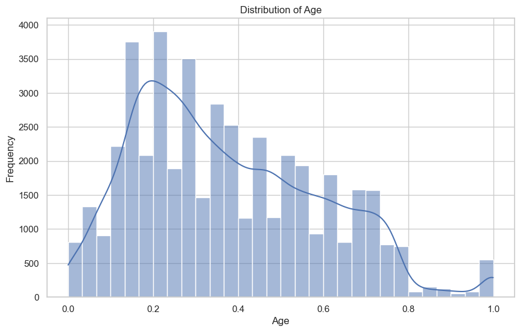

```python
import matplotlib.pyplot as plt
import seaborn as sns

sns.set(style="whitegrid")

# Histogram for 'age'
plt.figure(figsize=(10, 6))
sns.histplot(train_df_encoded['age'], bins=30, kde=True)
plt.title('Distribution of Age')
plt.xlabel('Age')
plt.ylabel('Frequency')
plt.show()
```

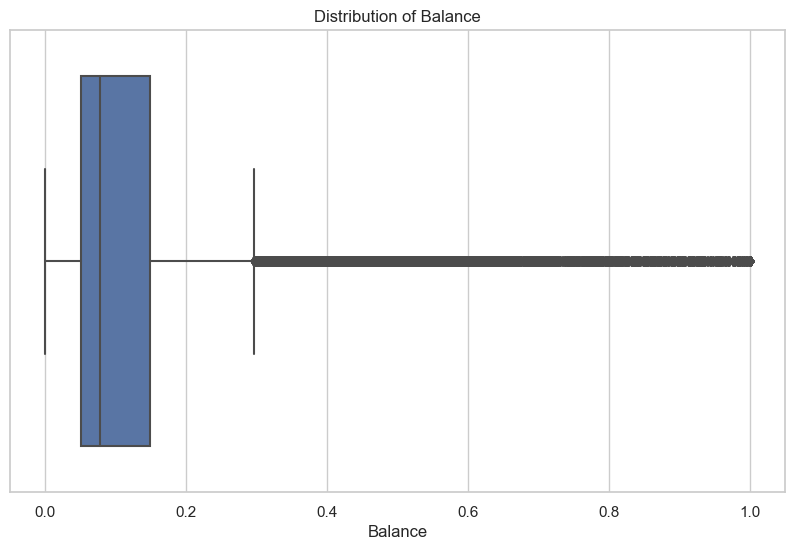

```python
# Box plot for 'balance'
plt.figure(figsize=(10, 6))
sns.boxplot(x=train_df_encoded['balance'])
plt.title('Distribution of Balance')
plt.xlabel('Balance')
plt.show()
```

[figure not shown]

```python
# Correlation matrix
plt.figure(figsize=(12, 8))
correlation_matrix = train_df_encoded.corr()
sns.heatmap(correlation_matrix, annot=True, cmap='coolwarm', linewidths=0.5)
plt.title('Correlation Matrix of Numerical Features')
plt.show()
```

**Deliverable:** Submit the visualizations and a written content (max 300 words) summarizing the findings from your EDA, highlighting interesting patterns, correlations, or trends.

**Summary of Findings:**

1. **Age Distribution:**
   - The age distribution is fairly normal with a slight right skew, indicating that most customers are middle-aged. This suggests that the bank's marketing campaigns are reaching a diverse age group, but there is a higher concentration of middle-aged customers.
2. **Balance Distribution:**
   - The balance feature has a significant number of outliers, even after capping. This indicates a wide range of account balances among customers, suggesting that the bank serves both low and high net-worth individuals. The presence of outliers may also indicate potential opportunities for targeted financial products.
3. **Duration of Last Contact:**
   - The duration of the last contact varies widely, with some interactions lasting only a few seconds and others lasting several minutes. Longer durations may indicate more engaged customers who are more likely to subscribe to a term deposit.
4. **Correlation Matrix:**
   - The correlation matrix shows that most numerical features have low correlation with each other, except for some expected relationships (e.g., pdays and previous). This suggests that each feature provides unique information, which can be valuable for building predictive models.
5. **Campaign Effectiveness:**
   - The number of contacts performed during the campaign (campaign) and the number of days since the client was last contacted (pdays) show interesting patterns. Customers who were contacted more frequently during the campaign or had a recent previous contact may have different subscription rates.

These insights provide a deeper understanding of the customer base and their interactions with the bank's marketing campaigns. The visualizations and summary statistics help identify key patterns and trends that can inform marketing strategies and improve customer targeting.